# TIGPS2023主要照顧者問卷成果報告

#感謝您參與中央研究院臺灣數位世代青少年的成長歷程追蹤研究計畫，本研究第一年完成訪問的學生來自全國170多所不同的學校，共計8,958位。每位學生可以有兩位主要照顧者填寫主要照顧者問卷，2023年共計回收4,444份主要照顧者問卷，以下是問卷的調查結果，歡迎參閱！

### 照顧者類別 (樣本數=4444)

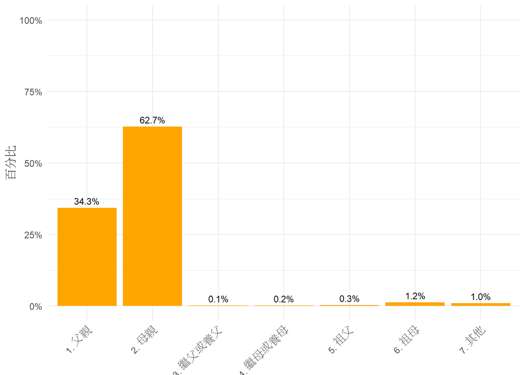

### 照顧者性別 (樣本數=4440)

[figure not shown]

### 族群、國籍 (樣本數=4406)

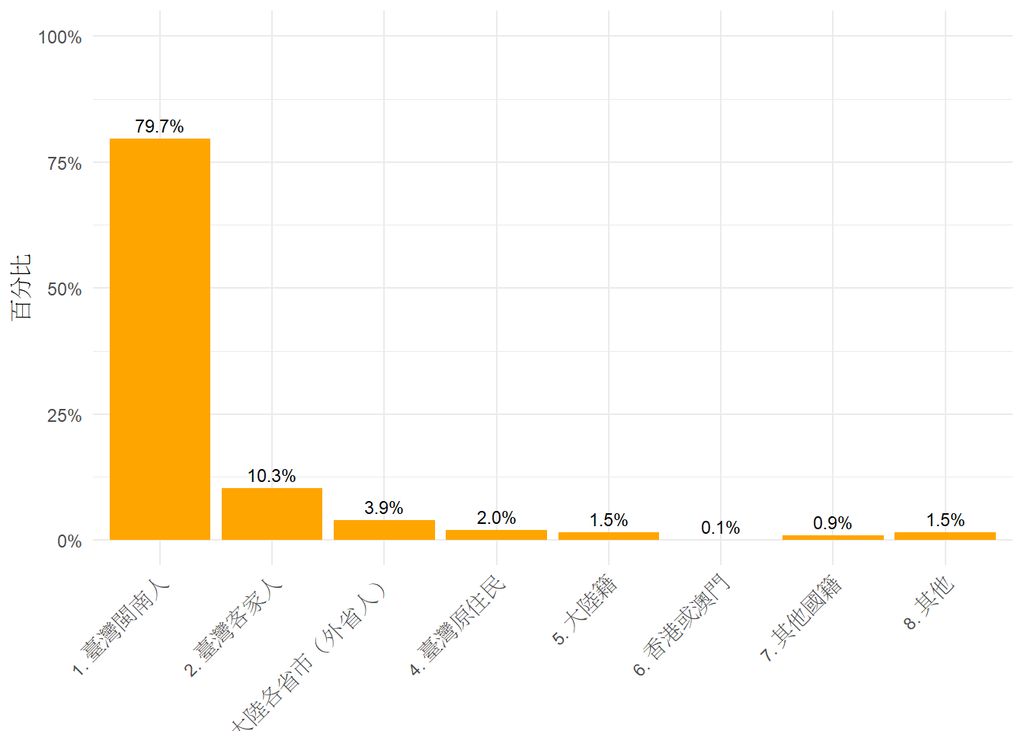

### 原住民族 (樣本數=86)

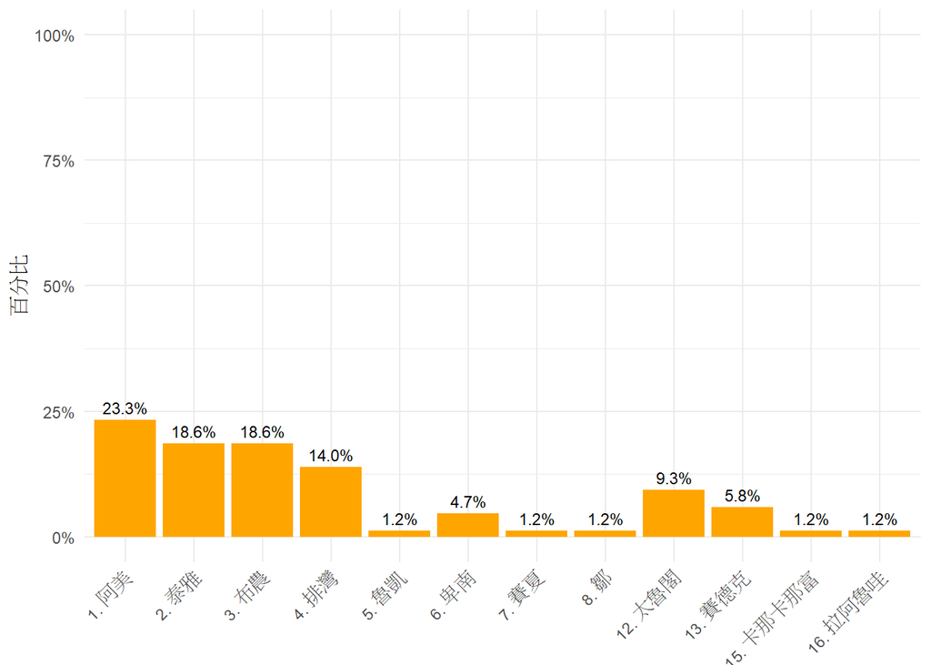

### 國籍 (樣本數=41)

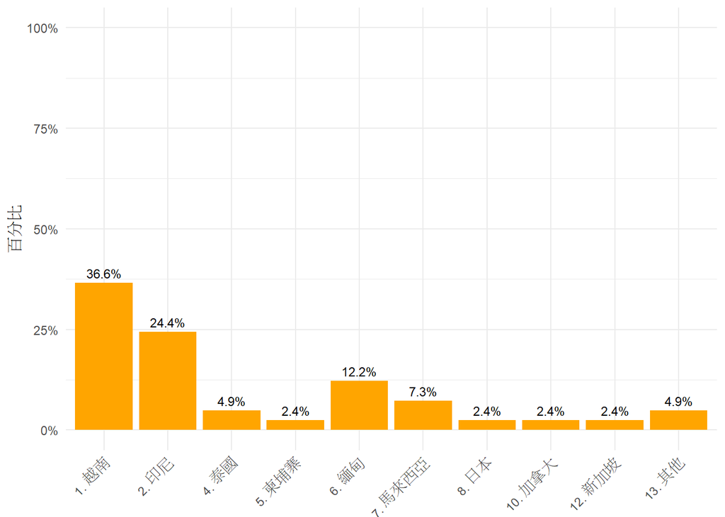

### 學歷 (樣本數=4401)

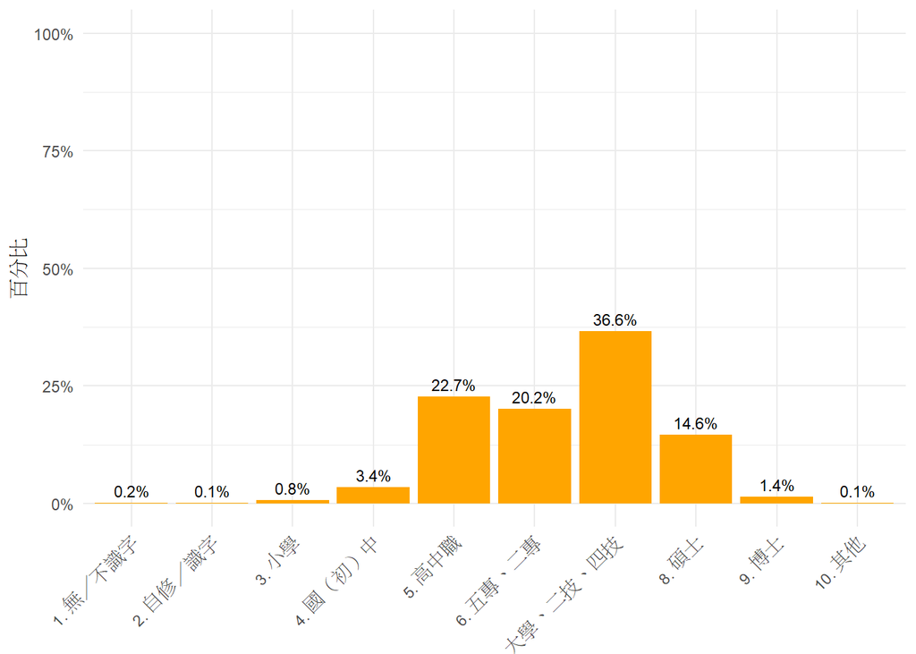

### 同住家人_配偶 (樣本數=4398)

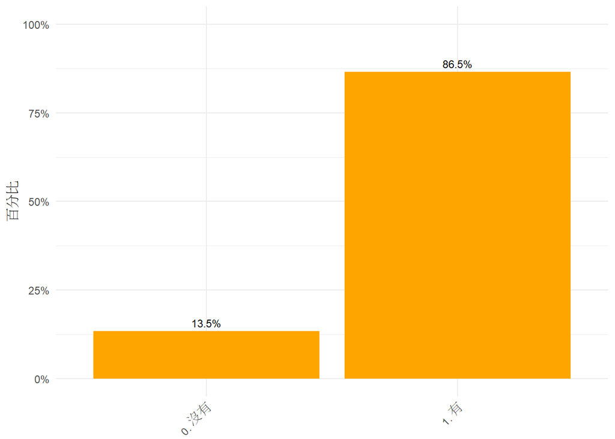

### 同住家人_父親 (樣本數=4398)

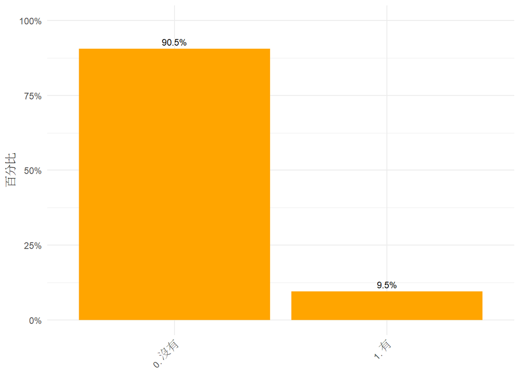

### 同住家人_母親 (樣本數=4398)

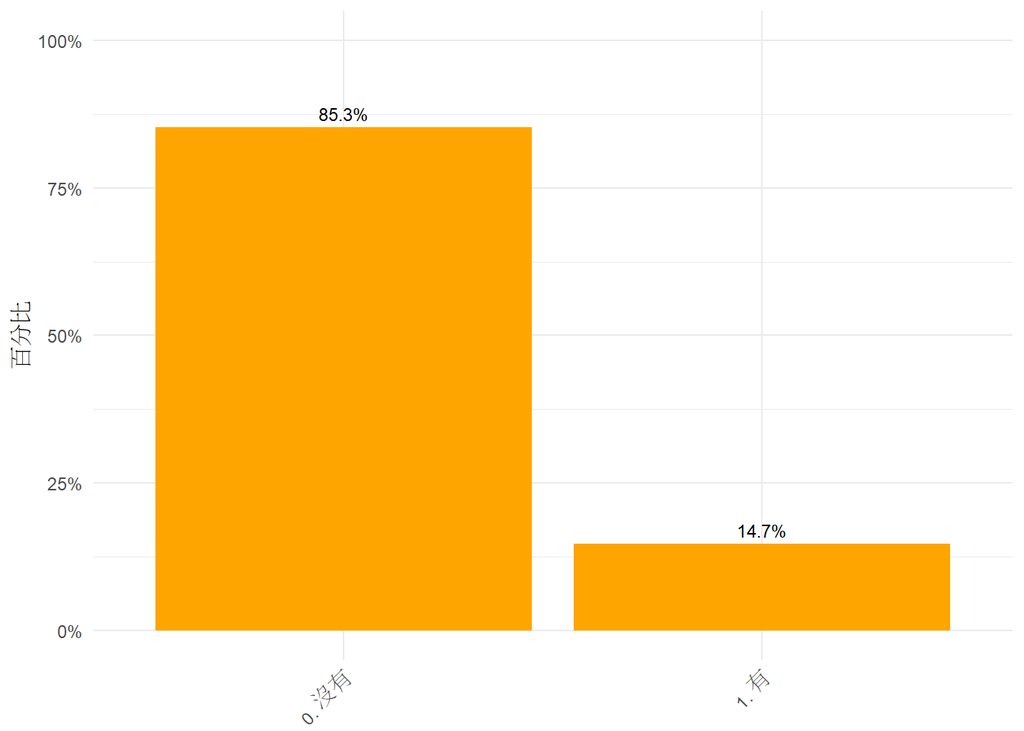

### 同住家人_配偶的父親 (樣本數=4398)

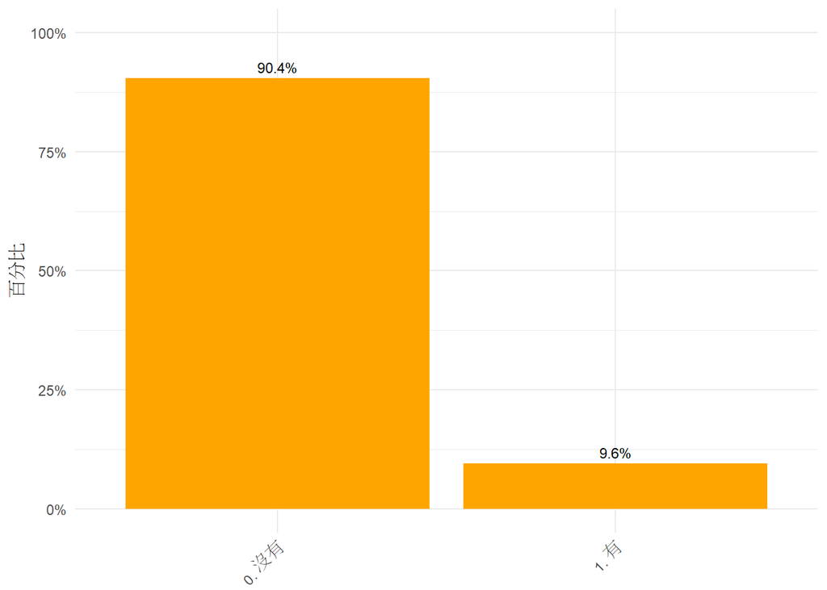

### 同住家人_配偶的母親 (樣本數=4398)

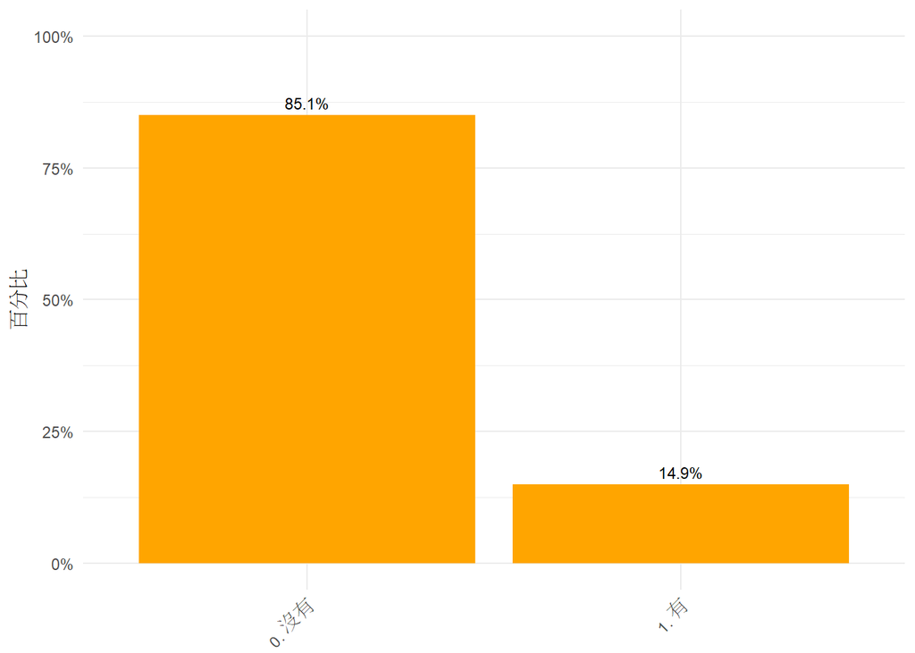

### 同住家人_未婚兒子 (樣本數=4398)

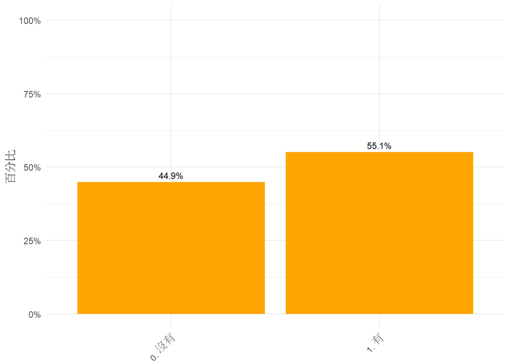

### 同住家人_未婚女兒 (樣本數=4398)

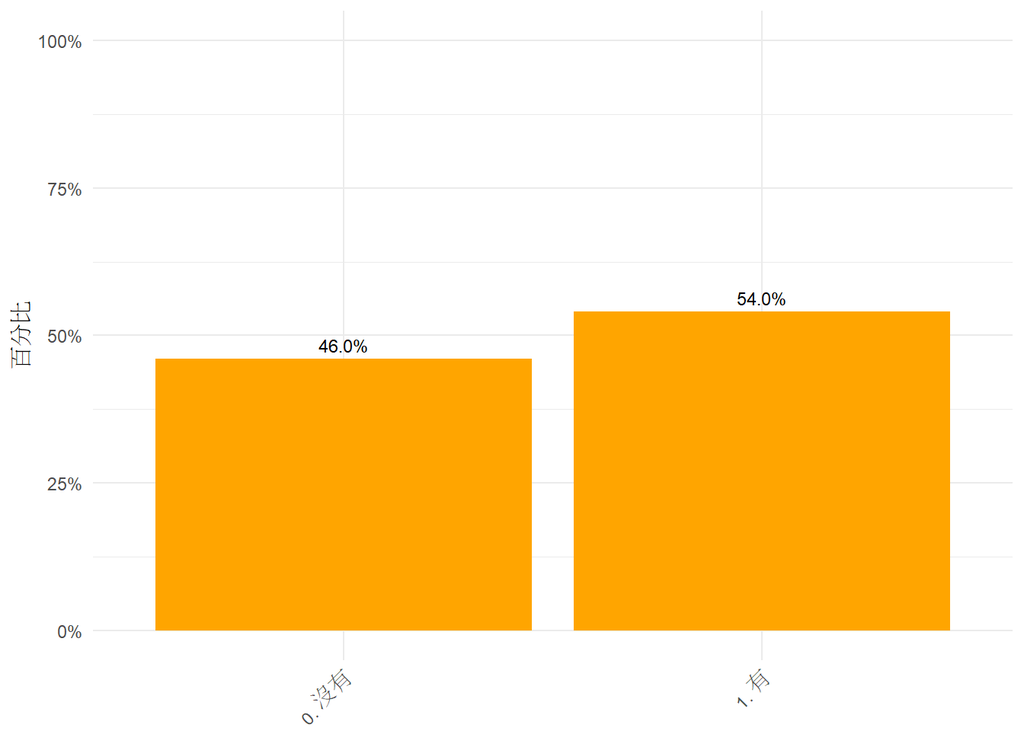

### 同住家人_已婚兒子 (樣本數=4398)

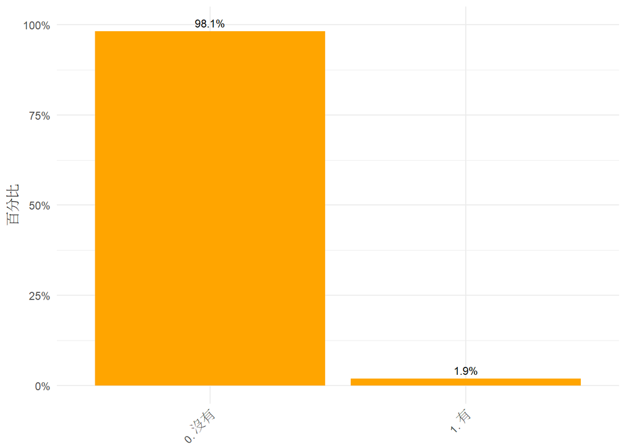

### 同住家人_媳婦 (樣本數=4398)

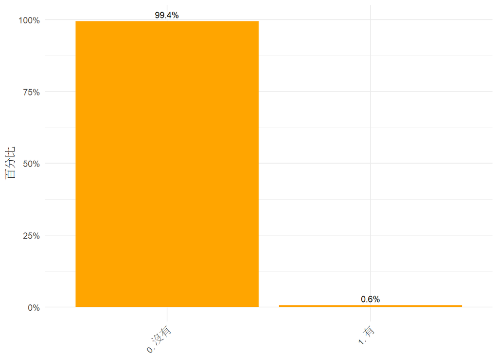

### 同住家人_已婚女兒 (樣本數=4398)

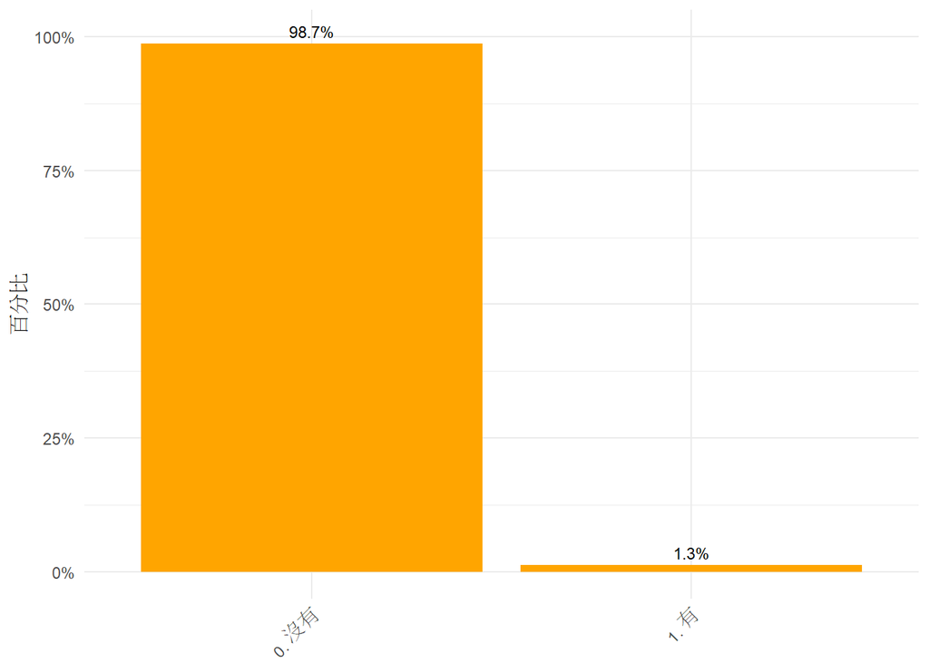

### 同住家人_女婿 (樣本數=4398)

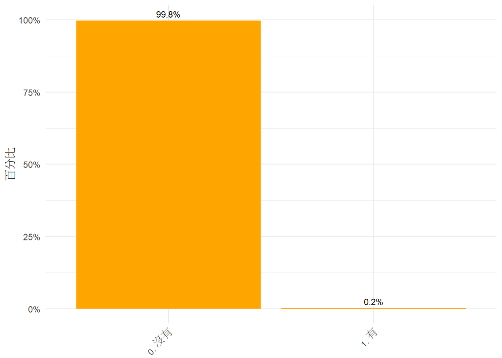

### 同住家人_看護或幫傭 (樣本數=4398)

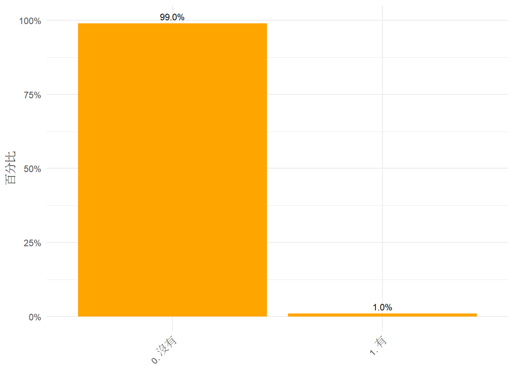

### 同住家人_其他 (樣本數=4398)

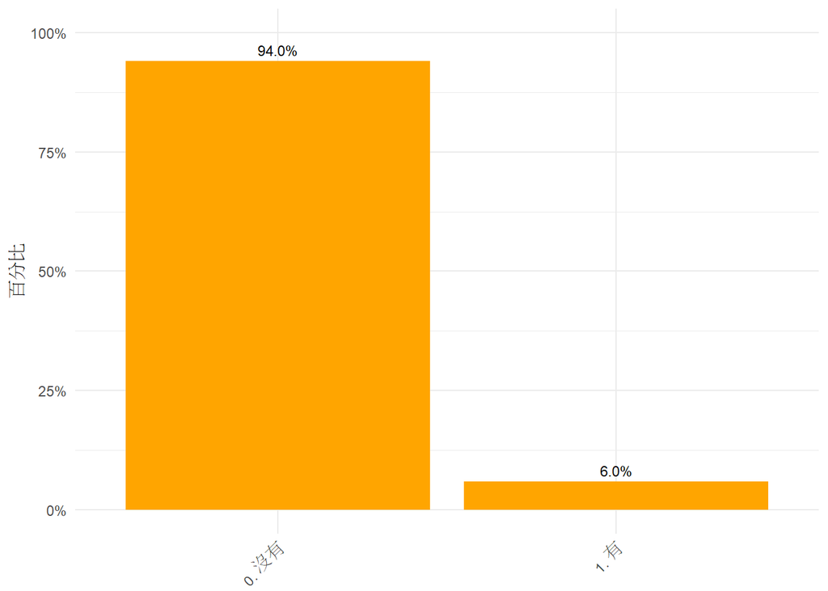

### 子女資料_數量 (樣本數=4400)

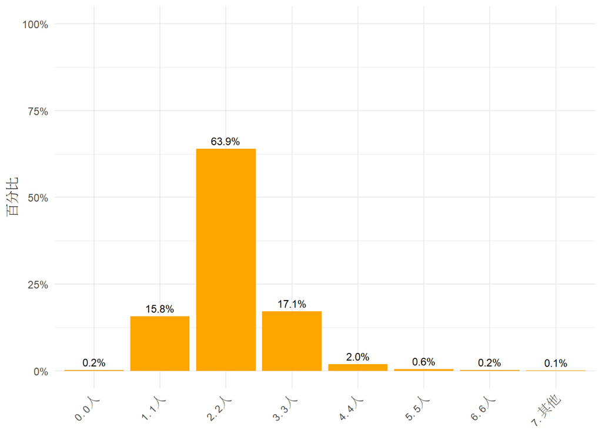

### 子女資料_男孩數量 (樣本數=3673)

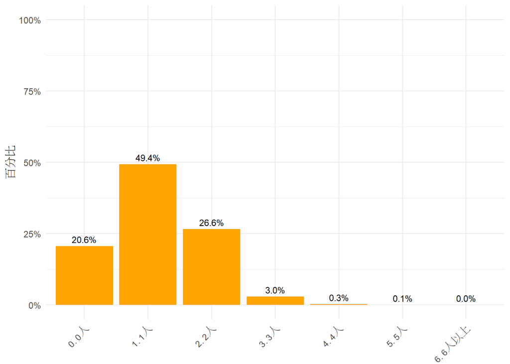

### 子女資料_女孩數量 (樣本數=3687)

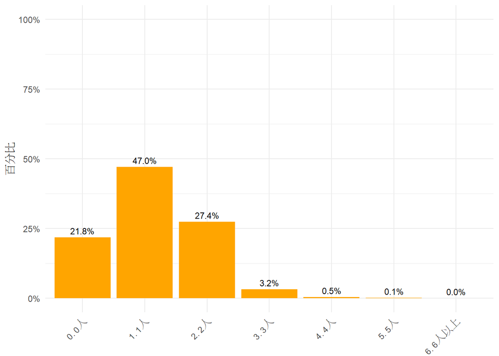

### 子女資料_有同胞胎手足嗎 (樣本數=3648)

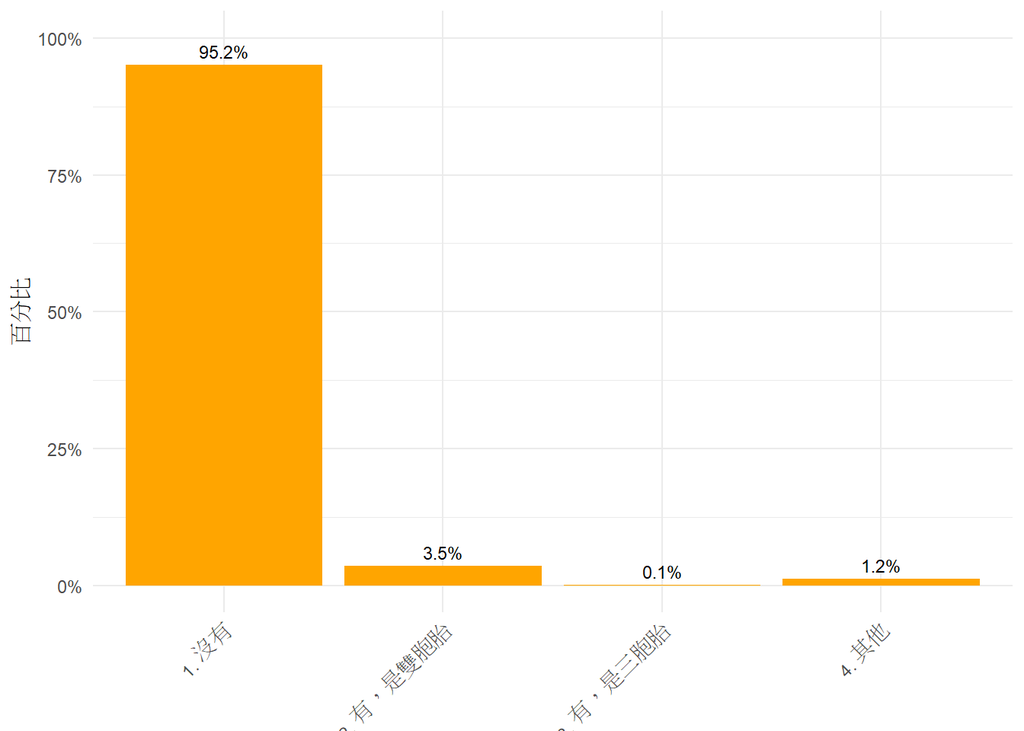

### 子女相處_孩子手足之間相處融洽，會相互照顧與分享 (樣本數=3653)

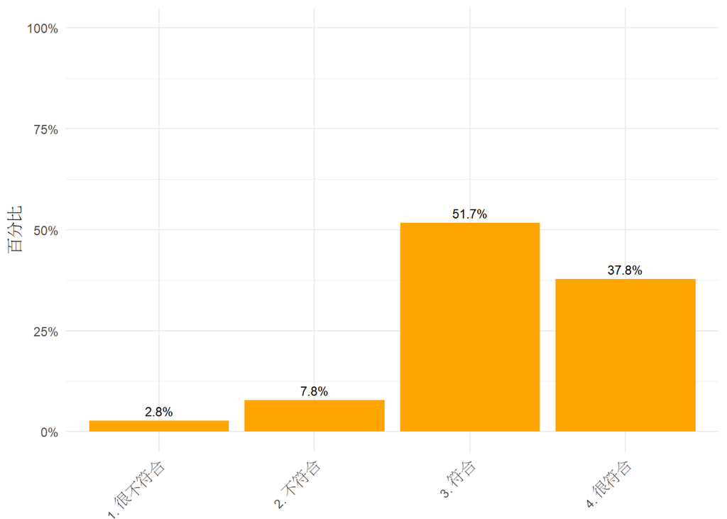

### 子女相處_孩子手足之間常有衝突 (樣本數=3635)

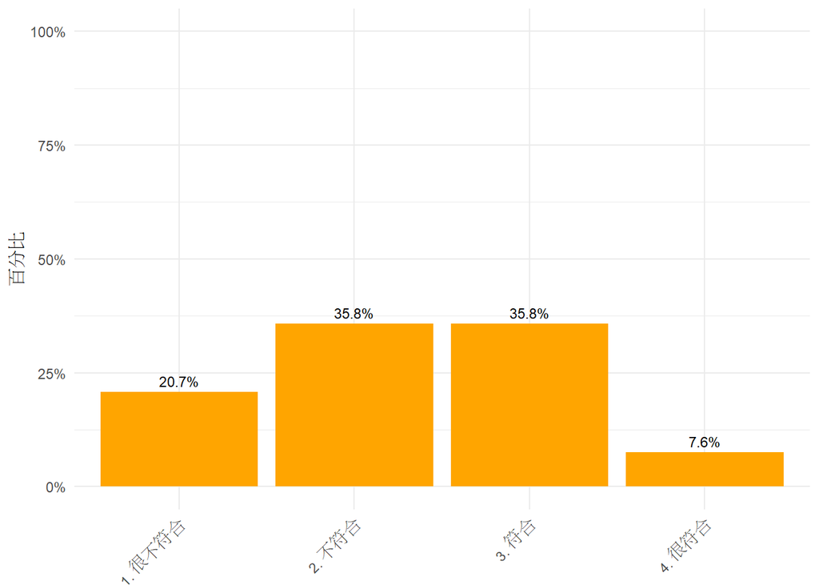

### 子女相處_孩子手足之間會彼此互相比較 (樣本數=3651)

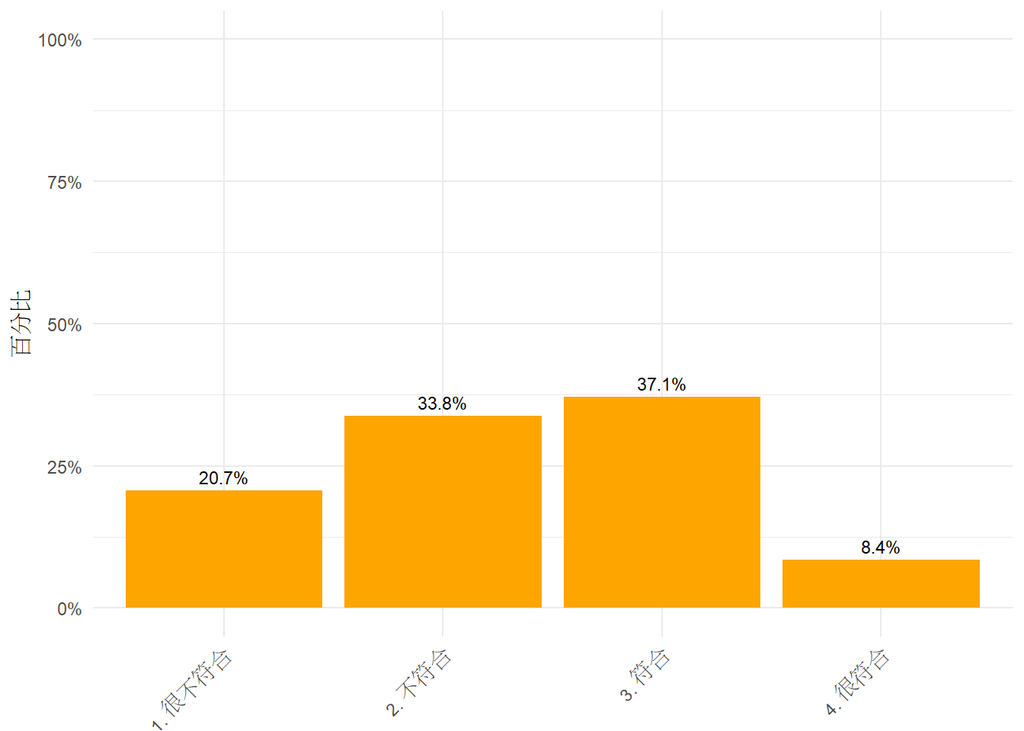

### 上一代_自己父親年齡 (樣本數=4058)

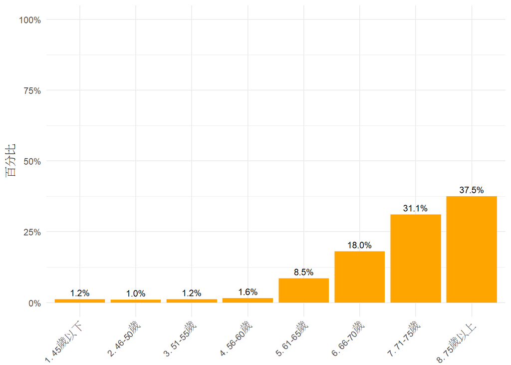

### 上一代_自己父親教育程度 (樣本數=3925)

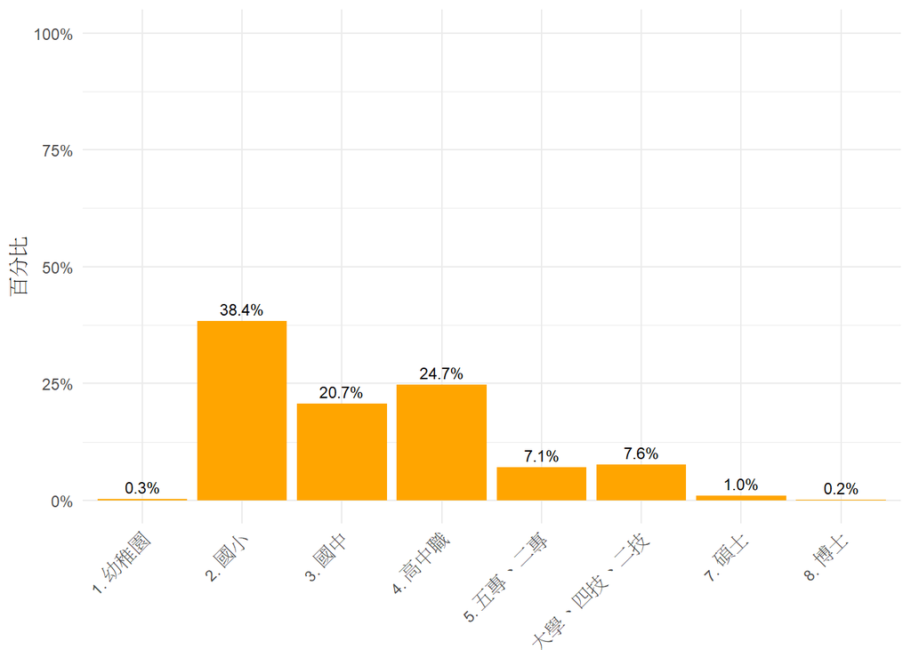

### 上一代_自己父親健康狀況 (樣本數=4200)

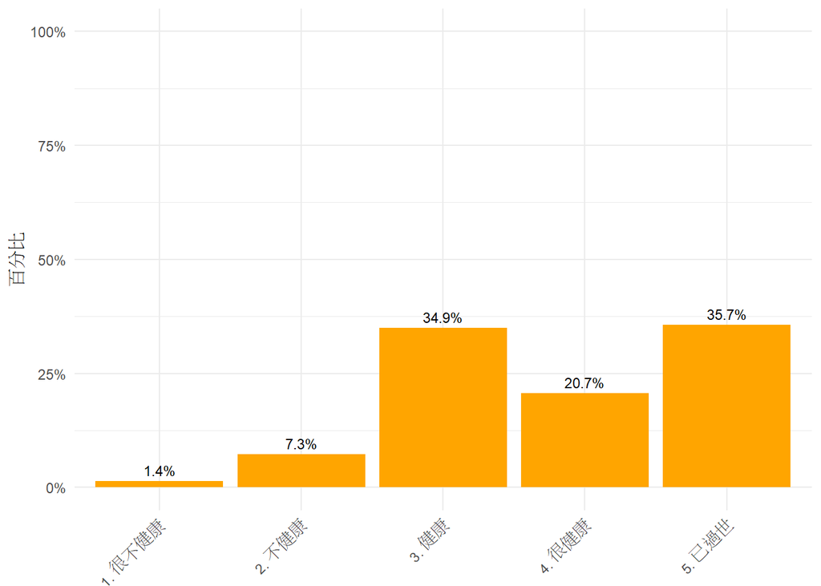

### 上一代_自己父親婚姻狀況 (樣本數=4226)

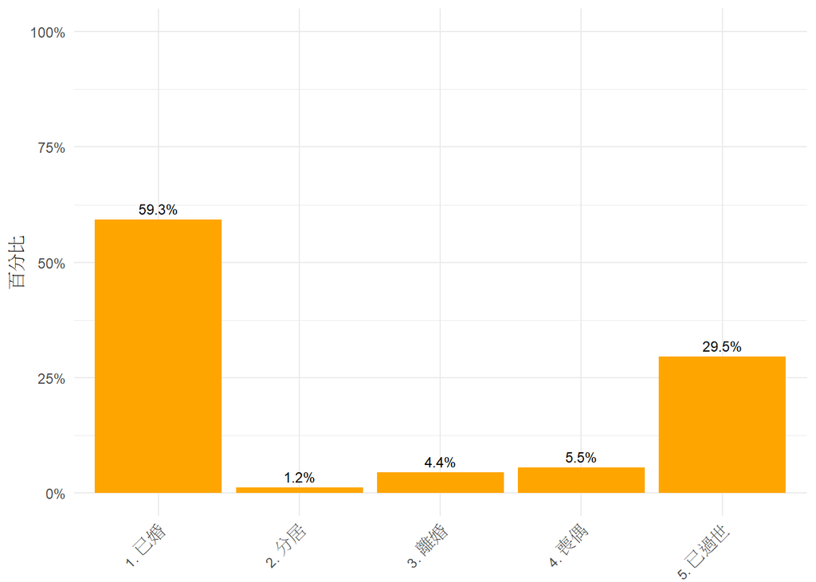

### 上一代_自己父親工作狀況 (樣本數=4188)

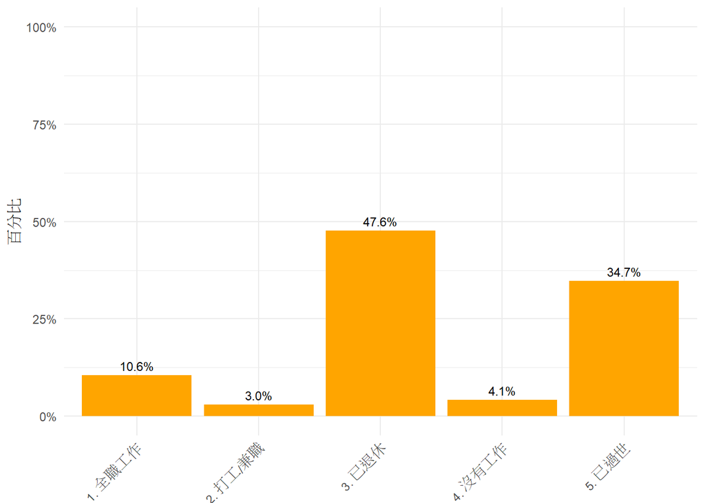